# PP-Plots

Gener Aviles-R, based on a blog previously published by John M Quick.

PP-Plots are a graphic representation of the probability calculated and probability observed in a dataset. Mostly used when evaluating model performance. In this excercise a PP-Plot will be used in the process of evaluating a linear model from [enrollment at the University of New Mexico](http://rtutorialseries.blogspot.in/2009/11/r-tutorial-series-simple-linear.html).

```r
dataset <- read.csv("D:/Dropbox/MsC UABC/2o Semestre/Clases/Estadistica/tareas/datasets/enrollmentNewMexico.csv")
#constructing linear model
lmVar <- lm(ROLL~UNEM, dataset)
```

### Obtaining values for the **lm** model.

```r
unstandPred <- predict(lmVar)
unstandResid <- resid(lmVar)
```

The values obtained with the previous lines of code are not standardized, which means that their range is way to different between these vairables, a **standardization** process will solve this problem and allow us to run analysis smoothly on them.

The following formula can be used to standardize a set of values:
$$Z = \frac{x-\mu}{\sigma}$$
Where $x$ is the value being standardized, $\mu$ is the mean of the variable to which the value belongs to and $\sigma$ is the standard deviation of the variable to which the value belongs to.

```r
standPred <- (unstandPred - mean(unstandPred)) / sd(unstandPred)
standResid <- (unstandResid - mean(unstandResid)) / sd(unstandResid)
```

### Calculating the probability distribution for residuals

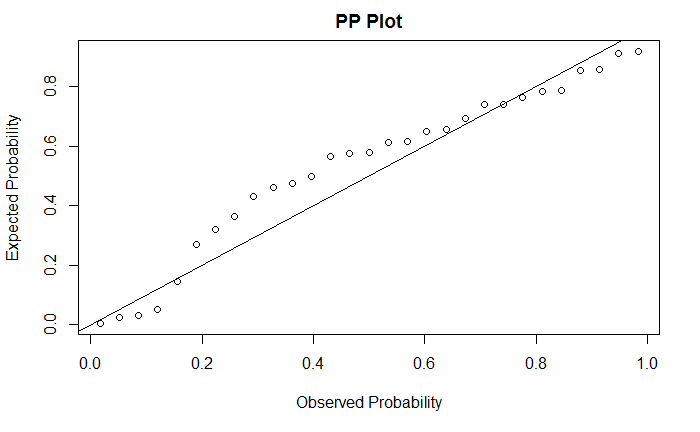

```r
probDist <- pnorm(standResid)
plot(ppoints(length(standResid)), sort(probDist), main = "PP Plot", xlab = "Observed Probability", ylab = "Expected Probability")
abline(0,1)
```

[figure not shown]

```r
pop<-c(20,23,24,24,24,25,29,31,31,33,34,36,36,37,39,39,40,40,41,45)
```